# Introduction to SNSeg and Examples

SNSeg supports change-points estimation for both univariate and multivariate time series (including high-dimensional time series with dimension greater than 10.) using Self-Normalization (SN) based framework. Please read Zhao, Jiang and Shao (2022) <doi.org/10.1111/rssb.12552> for details of the SN-based algorithms.

The package contain three functions for change-points estimation:

- The function `SNSeg_Uni` works for a univariate time series.
- The function `SNSeg_Multi` works for multivariate time series with dimension up to ten.
- The function `SNSeg_HD` works for high-dimensional time series with dimension above ten.

All functions contain two important input arguments: `grid_size_scale` and `grid_size`.

- `grid_size_scale`: the trimming parameter $\epsilon$, a parameter to control the local window size `grid_size`. The range of `grid_size_scale` should be between 0.05 and 0.5. Any input `grid_size_scale` smaller than 0.05 will be automatically changed to 0.05, and any input `grid_size_scale` greater than 0.5 will be automatically changed to 0.5.
- `grid_size`: the local window size $h$ for local scanning for each time point. According to Zhao et al. (2022), `grid_size` is a product of `grid_size_scale` and the length of time.

Users can set their own `grid_size` or leave it as `NULL` in the input arguments. If `grid_size` is `NULL`, these functions will compute the SN test statistic using the value of `grid_size_scale`. If `grid_size` is set by users, the functions will first calculate `grid_size_scale` by diving the length of time, and then compute the SN test statistic.

For the other input arguments: * `ts`: Users should enter a time series for this argument. For `SNSeg_Uni`, the dimension of `ts` should be exactly one in most cases (or two when `paras_to_test = 'bivcor'`); for `SNSeg_Multi`, the dimension must be at least two but no more than ten; for `SNSeg_HD`, the dimension must be greater than ten. * `paras_to_test`: This argument in functions `SNSeg_Uni` and `SNSeg_Multi` allows users to enter the parameter(s) they would like to test the change in. * `confidence`: Users should choose a confidence level among 0.9, 0.95, 0.99, 0.995 and 0.995. A smaller confidence level is easier to reject the null hypothesis and detect a change-point.

The package also offers an option to plot the time series (this only works for the univariate time series cases!) Users need to set `plot_SN = TRUE` to visualize the time series, and `est_cp_loc = TRUE` to add the estimated change-point locations in the plot.

## SN Test Statistic Plot: `max_SNsweep`

To visualize the computed SN-based test statistic at each time point, users can apply the function `max_SNsweep` by plugging in the output object from one of the functions `SNSeg_Uni`, `SNSeg_Multi` and `SNSeg_HD`. The options `est_cp_loc = TRUE` and `critical_loc = TRUE` are provided to draw the estimated change-point locations and the critical value threshold inside the test statistic plot.

`max_SNsweep` also returns the SN-based test statistic for each time point. A large number of test statistics in the output can be messy for users who only seek to generate a plot. To hide the test statistics output, users can create an arbitrary variable name and set it to the `max_SNsweep` function, e.g., `SN_stat <- max_SNsweep(...)`.

## Parameter Estimates of Each Segment Separated by the Detected Change-Points: `SNSeg_estimate`

The function `SNSeg_estimate` allows users to compute the parameter estimates (e.g., mean, variance, acf, quantile, etc.) of each of the segments separated by the estimated change-points. To use this function, users should use the output of the functions `SNSeg_Uni`, `SNSeg_Multi` and `SNSeg_HD` as the input of `SNSeg_estimate`.

## S3 methods: summary, print and plot

We then provide the examples of the functions `SNSeg_Uni`, `SNSeg_Multi` and `SNSeg_HD`.

## Examples of `SNSeg_Uni`:

The function `SNSeg_Uni` detect change-points for a univariate time series based on the change in a single or parameters.

- For a univariate time series, the input argument `paras_to_test` allows one or a combination of multiple parameters from “mean”, “variance”, “acf” and a numeric quantile value between 0 and 1. For instance, to test the change in autocorrelation and 80th quantile, users should set `paras_to_test` to c(‘acf’, 0.8).
- To test the change in correlation between two univariate time series, the input time series must be two-dimensional and `paras_to_test` should be set to `bivcor`.
- Users can also set `paras_to_test` using their own parameters. In this case, the input of `paras_to_test` needs to be a function which returns a numeric value.

We provide examples for different cases:

```r
# Please run the following function before running examples:
mix_GauGPD <- function(u,p,trunc_r,gpd_scale,gpd_shape){
  indicator <- u<p
  rv <- rep(0, length(u))
  rv[indicator>0] <- qtruncnorm(u[indicator>0]/p,a=-Inf,b=trunc_r)
  rv[indicator<=0] <- qgpd((u[indicator<=0]-p)/(1-p), loc=trunc_r, scale=gpd_scale,shape=gpd_shape)
  return(rv)
}
```

## Test in a single parameter

### Segmentation for Mean

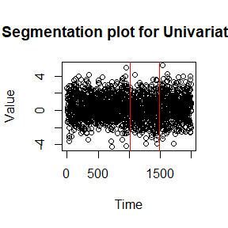

```r
set.seed(7)
n <- 2000
reptime <- 2
cp_sets <- round(n*c(0,cumsum(c(0.5,0.25)),1))
mean_shift <- c(0.4,0,0.4)
rho <- -0.7
ts <- MAR(n, reptime, rho)
no_seg <- length(cp_sets)-1
for(index in 1:no_seg){ # Mean shift
  tau1 <- cp_sets[index]+1
  tau2 <- cp_sets[index+1]
  ts[tau1:tau2,] <- ts[tau1:tau2,] + mean_shift[index]
}
ts <- ts[,2]
# grid_size undefined
result <- SNSeg_Uni(ts, paras_to_test = "mean", confidence = 0.9,
                    grid_size_scale = 0.05, grid_size = NULL,
                    plot_SN = FALSE, est_cp_loc = FALSE)
# grid_size defined & generate time series segmentation plot
result <- SNSeg_Uni(ts, paras_to_test = "mean", confidence = 0.9,
                    grid_size_scale = 0.05, grid_size = 116,
                    plot_SN = TRUE, est_cp_loc = TRUE)
```

```r
# Estimated change-point locations
result$est_cp
```

```
#> [1] 1018 1487
```

```r
# Parameter estimates (mean) of each segment
SNSeg_estimate(result)
```

```
#> $mean
#> [1] 0.39444849 0.02107613 0.38362925
#>
#> attr(,"class")
#> [1] "SNSeg_estimate"
```

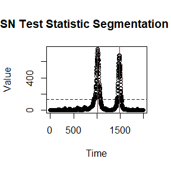

```r
# plot the SN-based test statistic
SN_stat <- max_SNsweep(result, plot_SN = TRUE, est_cp_loc = TRUE,
                       critical_loc = TRUE)
```

We then show how to use the S3 methods `summary`, `print` and `plot`.

```r
summary(result)
```

```
#> There are 2 change-point(s) detected at 90th confidence level based on the change in the single mean parameter.
#>
#> The critical value of SN-based test is 135.39283594
#>
#> The detected change-point location(s) are 1018,1487 with a grid_size of 116
```

```r
print(result)
```

```
#> The detected change-point location(s) are 1018,1487
```

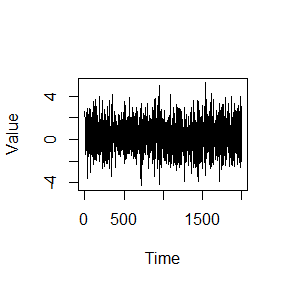

```r
plot(result, cpts.col = 'red')
```

### Segmentation for Variance

```r
set.seed(7)
ts <- MAR_Variance(2, "V1")
ts <- ts[,2]
# grid_size defined
result <- SNSeg_Uni(ts, paras_to_test = "variance", confidence = 0.9,
                    grid_size_scale = 0.05, grid_size = NULL,
                    plot_SN = FALSE, est_cp_loc = TRUE)
# Estimated change-point locations
result$est_cp
```

```
#> [1] 401 738
```

```r
# Parameter estimates (variance) of each segment
SNSeg_estimate(result)
```

```
#> $variance
#> [1] 1.440844 5.572523 1.530858
#>
#> attr(,"class")
#> [1] "SNSeg_estimate"
```

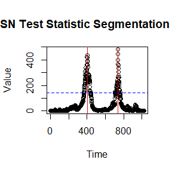

```r
# plot the SN-based test statistic
SN_stat <- max_SNsweep(result, plot_SN = TRUE, est_cp_loc = TRUE,
                       critical_loc = TRUE)
```

```r
summary(result)
```

```
#> There are 2 change-point(s) detected at 90th confidence level based on the change in the single variance parameter.
#>
#> The critical value of SN-based test is 141.8941189
#>
#> The detected change-point location(s) are 401,738 with a grid_size of 51
```

```r
print(result)
```

```
#> The detected change-point location(s) are 401,738
```

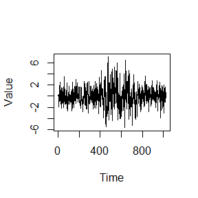

```r
plot(result, cpts.col = 'red')
```

### Segmentation for Autocorrelation

```r
set.seed(7)
ts <- MAR_Variance(2, "A3")
ts <- ts[,2]
# grid_size defined
result <- SNSeg_Uni(ts, paras_to_test = "acf", confidence = 0.9,
          grid_size_scale = 0.05, grid_size = 92, plot_SN = FALSE,
          est_cp_loc = TRUE)
# Estimated change-point locations
result$est_cp
```

```
#> [1] 491 767
```

```r
# Parameter estimates (acf) of each segment
SNSeg_estimate(result)
```

```
#> $acf
#> [1] -0.2988717  0.8969656 -0.4986537
#>
#> attr(,"class")
#> [1] "SNSeg_estimate"
```

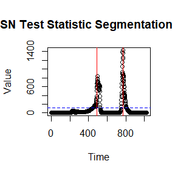

```r
# plot the SN-based test statistic
SN_stat <- max_SNsweep(result, plot_SN = TRUE, est_cp_loc = TRUE,
                       critical_loc = TRUE)
```

```r
summary(result)
```

```
#> There are 2 change-point(s) detected at 90th confidence level based on the change in the single acf parameter.
#>
#> The critical value of SN-based test is 114.870563617187
#>
#> The detected change-point location(s) are 491,767 with a grid_size of 92
```

```r
print(result)
```

```
#> The detected change-point location(s) are 491,767
```

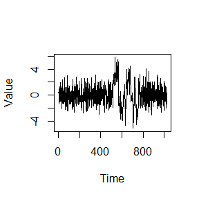

```r
plot(result, cpts.col = 'red')
```

### Segmentation for bivariate correlation

```r
library(mvtnorm)
set.seed(7)
n <- 1000
sigma_cross <- list(4*matrix(c(1,0.8,0.8,1), nrow=2),
                    matrix(c(1,0.2,0.2,1), nrow=2),
                    matrix(c(1,0.8,0.8,1), nrow=2))
cp_sets <- round(c(0,n/3,2*n/3,n))
noCP <- length(cp_sets)-2
rho_sets <- rep(0.5, noCP+1)
ts <- MAR_MTS_Covariance(n, 2, rho_sets, cp_sets, sigma_cross)
ts <- ts[1][[1]]
# grid_size defined
result <- SNSeg_Uni(ts, paras_to_test = "bivcor", confidence = 0.9,
                    grid_size_scale = 0.05, grid_size = 77,
                    plot_SN = FALSE, est_cp_loc = TRUE)
# Estimated change-point locations
result$est_cp
```

```
#> [1] 336 667
```

```r
# Parameter estimates (bivariate correlation) of each segment
SNSeg_estimate(result)
```

```
#> $bivcor
#> [1] 0.7862169 0.2308723 0.8062517
#>
#> attr(,"class")
#> [1] "SNSeg_estimate"
```

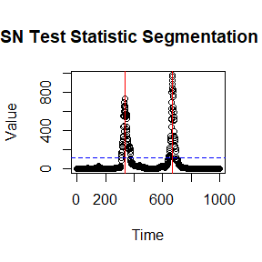

```r
# plot the SN-based test statistic
SN_stat <- max_SNsweep(result, plot_SN = TRUE, est_cp_loc = TRUE,
                       critical_loc = TRUE)
```

```r
summary(result)
```

```
#> There are 2 change-point(s) detected at 90th confidence level based on the change in the single bivcor parameter.
#>
#> The critical value of SN-based test is 122.32314655
#>
#> The detected change-point location(s) are 336,667 with a grid_size of 77
```

```r
print(result)
```

```
#> The detected change-point location(s) are 336,667
```

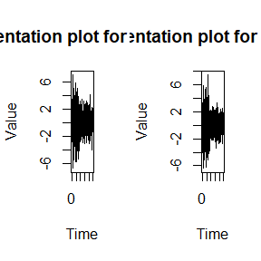

```r
plot(result, cpts.col = 'red')
```

### Segmentation for quantile

```r
library(truncnorm)
```

```r
library(evd)
set.seed(7)
n <- 1000
cp_sets <- c(0,n/2,n)
noCP <- length(cp_sets)-2
reptime <- 2
rho <- 0.2
# AR time series with no change-point (mean, var)=(0,1)
ts <- MAR(n, reptime, rho)*sqrt(1-rho^2)
trunc_r <- 0
p <- pnorm(trunc_r)
gpd_scale <- 2
gpd_shape <- 0.125
for(ts_index in 1:reptime){
  ts[(cp_sets[2]+1):n, ts_index] <- mix_GauGPD(pnorm(ts[(cp_sets[2]+1):n, ts_index]),
p,trunc_r,gpd_scale,gpd_shape)
}
ts <- ts[,2]
# grid_size undefined
# test in 90% quantile
result <- SNSeg_Uni(ts, paras_to_test = 0.9, confidence = 0.9,
                    grid_size_scale = 0.066, grid_size = NULL,
                    plot_SN = FALSE, est_cp_loc = TRUE)
# Estimated change-point locations
result$est_cp
```

```
#> [1] 487
```

```r
# Parameter estimates (90th quantile) of each segment
SNSeg_estimate(result)
```

```
#> $quantile
#> [1] 1.387091 3.736573
#>
#> attr(,"class")
#> [1] "SNSeg_estimate"
```

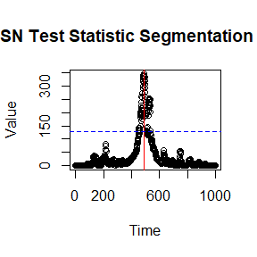

```r
# plot the SN-based test statistic
SN_stat <- max_SNsweep(result, plot_SN = TRUE, est_cp_loc = TRUE,
                       critical_loc = TRUE)
```

```r
summary(result)
```

```
#> There are 1 change-point(s) detected at 90th confidence level based on the change in the 90th quantile.
#>
#> The critical value of SN-based test is 129.82941184
#>
#> The detected change-point location(s) are 487 with a grid_size of 66
```

```r
print(result)
```

```
#> The detected change-point location(s) are 487
```

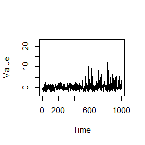

```r
plot(result, cpts.col = 'red')
```

### Test in a general functional

```r
set.seed(7)
n <- 500
reptime <- 2
cp_sets <- round(n*c(0,cumsum(c(0.5,0.25)),1))
mean_shift <- c(0.4,0,0.4)
rho <- -0.7
ts <- MAR(n, reptime, rho)
no_seg <- length(cp_sets)-1
for(index in 1:no_seg){ # Mean shift
  tau1 <- cp_sets[index]+1
  tau2 <- cp_sets[index+1]
  ts[tau1:tau2,] <- ts[tau1:tau2,] + mean_shift[index]
}
ts <- ts[,2]
# set a general functional for the input 'paras_to_test'
paras_to_test = function(ts){
  mean(ts)
}
result.SNCP.general <- SNSeg_Uni(ts, paras_to_test = paras_to_test,
                                 confidence = 0.9, grid_size_scale = 0.05,
                                 grid_size = NULL, plot_SN = FALSE,
                                 est_cp_loc = TRUE)
# Estimated change-point locations
result.SNCP.general$est_cp
```

```
#> [1] 263 365
```

```r
# Parameter estimates (general functional) of each segment
SNSeg_estimate(result.SNCP.general)
```

```
#> $general
#> [1]  0.3942287 -0.1211077  0.3942779
#>
#> attr(,"class")
#> [1] "SNSeg_estimate"
```

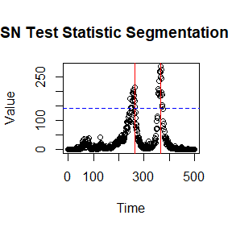

```r
# plot the SN-based test statistic
SN_stat <- max_SNsweep(result.SNCP.general, plot_SN = TRUE, est_cp_loc = TRUE,
                       critical_loc = TRUE)
```

```r
summary(result.SNCP.general)
```

```
#> There are 2 change-point(s) detected at 90th confidence level based on the change in the user-defined functional.
#>
#> The critical value of SN-based test is 141.8941189
#>
#> The detected change-point location(s) are 263,365 with a grid_size of 25
```

```r
print(result.SNCP.general)
```

```
#> The detected change-point location(s) are 263,365
```

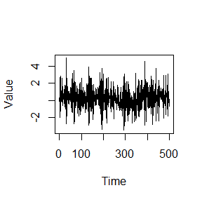

```r
plot(result.SNCP.general, cpts.col = 'red')
```

### Test in multiple parameters

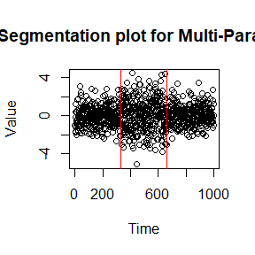

```r
set.seed(7)
n <- 1000
cp_sets <- c(0,333,667,1000)
no_seg <- length(cp_sets)-1
rho <- 0
# AR time series with no change-point (mean, var)=(0,1)
ts <- MAR(n, 2, rho)*sqrt(1-rho^2)
no_seg <- length(cp_sets)-1
sd_shift <- c(1,1.6,1)
for(index in 1:no_seg){ # Mean shift
  tau1 <- cp_sets[index]+1
  tau2 <- cp_sets[index+1]
  ts[tau1:tau2,] <- ts[tau1:tau2,]*sd_shift[index]
}
d <- 2
ts <- ts[,2]

# Test in 90th and 95th quantile with grid_size undefined
result <- SNSeg_Uni(ts, paras_to_test = c(0.9, 0.95), confidence = 0.9,
                    grid_size_scale = 0.05, grid_size = NULL,
                    plot_SN = FALSE, est_cp_loc = FALSE)

# Test in 90th quantile and the variance with grid_size undefined
result <- SNSeg_Uni(ts, paras_to_test = c(0.9, 'variance'),
                    confidence = 0.95, grid_size_scale = 0.078,
                    grid_size = NULL, plot_SN = FALSE,
                    est_cp_loc = FALSE)

# Test in 90th quantile, variance and acf with grid_size undefined
result <- SNSeg_Uni(ts, paras_to_test = c(0.9,'variance', "acf"),
                    confidence = 0.9, grid_size_scale = 0.064,
                    grid_size = NULL, plot_SN = TRUE,
                    est_cp_loc = TRUE)
```

```r
# Estimated change-point locations
result$est_cp
```

```
#> [1] 327 659
```

```r
# Test in 60th quantile, mean, variance and acf with grid_size defined
result.last <- SNSeg_Uni(ts, paras_to_test = c(0.6, 'mean', "variance",
                    "acf"), confidence = 0.9, grid_size_scale = 0.05,
                    grid_size = 83, plot_SN = FALSE, est_cp_loc = TRUE)
# Estimated change-point locations
result.last$est_cp
```

```
#> [1] 321 660
```

```r
# Parameter estimates (of the last example) of each segment
SNSeg_estimate(result.last)
```

```
#> $mean
#> [1] -0.04086428  0.08603419  0.03830652
#>
#> $variance
#> [1] 1.031635 2.769062 1.003470
#>
#> $acf
#> [1]  0.0009477774  0.0943055212 -0.0630678502
#>
#> $quantile
#>         0.6
#> 1 0.1673911
#> 2 0.5931716
#> 3 0.2747231
#>
#> attr(,"class")
#> [1] "SNSeg_estimate"
```

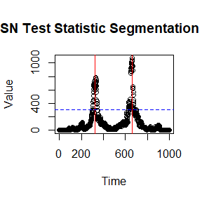

```r
# SN-based test statistic segmentation plot
SN_stat <- max_SNsweep(result.last, plot_SN = TRUE, est_cp_loc = TRUE,
                       critical_loc = TRUE)
```

```r
summary(result.last)
```

```
#> There are 2 change-point(s) detected at 90th confidence level based on the change in multiple parameters.
#>
#> The parameters being tested are 60th quantile, mean , variance , acf ,
#>
#> The critical value of SN-based test is 306.697106637346
#>
#> The detected change-point location(s) are 321,660 with a grid_size of 83
```

```r
print(result.last)
```

```
#> The detected change-point location(s) are 321,660
```

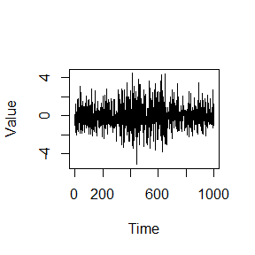

```r
plot(result.last, cpts.col = 'red')
```

## Examples: `SNSeg_Multi`

The function `SNSeg_Multi` detects change-points for multivariate time series based on the change in multivariate means or covariances. Users can set `paras_to_test` to `mean` or `covariance` for change-points estimation.

- The dimension of parameters to be tested must be at most ten. If the parameter is `mean`, the dimension is equivalent to the number of time series. If the parameter is `covariance`, the dimension is equivalent to the number of unknown parameters within the covariance matrix.

For examples of multivariate means and covariances, please check the following commands:

```r
# Please run this function before running examples:
exchange_cor_matrix <- function(d, rho){
  tmp <- matrix(rho, d, d)
  diag(tmp) <- 1
  return(tmp)
}
```

### Segmentation for Multivariate Mean

```r
library(mvtnorm)
set.seed(10)
d <- 5
n <- 1000
cp_sets <- round(n*c(0,cumsum(c(0.075,0.3,0.05,0.1,0.05)),1))
mean_shift <- c(-3,0,3,0,-3,0)/sqrt(d)
mean_shift <- sign(mean_shift)*ceiling(abs(mean_shift)*10)/10
rho_sets <- 0.5
sigma_cross <- list(exchange_cor_matrix(d,0))
ts <- MAR_MTS_Covariance(n, 2, rho_sets, cp_sets=c(0,n), sigma_cross)
noCP <- length(cp_sets)-2
no_seg <- length(cp_sets)-1
for(rep_index in 1:2){
  for(index in 1:no_seg){ # Mean shift
    tau1 <- cp_sets[index]+1
    tau2 <- cp_sets[index+1]
    ts[[rep_index]][,tau1:tau2] <- ts[[rep_index]][,tau1:tau2] + mean_shift[index]
    }
}
ts <- ts[1][[1]]

# grid_size undefined
result <- SNSeg_Multi(ts, paras_to_test = "mean", confidence = 0.95,
                      grid_size_scale = 0.079, grid_size = NULL,
                      plot_SN = FALSE, est_cp_loc = TRUE)
# grid_size defined
result <- SNSeg_Multi(ts, paras_to_test = "mean", confidence = 0.99,
                      grid_size_scale = 0.05, grid_size = 65,
                      plot_SN = FALSE, est_cp_loc = TRUE)
# Estimated change-point locations
result$est_cp
```

```
#> [1] 73
```

```r
# Parameter estimates (multivariate mean) of each segment
SNSeg_estimate(result)
```

```
#> $multi_mean
#>           ts1        ts2        ts3         ts4          ts5
#> 1 -1.98767415 -1.2860977 -1.7489535 -1.44241877 -0.854778164
#> 2  0.06754981 -0.1113808  0.1104449 -0.03328591 -0.009844436
#>
#> attr(,"class")
#> [1] "SNSeg_estimate"
```

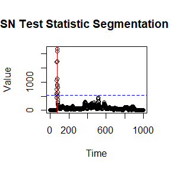

```r
# SN-based test statistic segmentation plot
SN_stat <- max_SNsweep(result, plot_SN = TRUE, est_cp_loc = TRUE,
                       critical_loc = TRUE)
```

```r
summary(result)
```

```
#> meanThere are 1 change-points detected at 99th confidence level based on the change in multivariate
#>
#> The detected change-point location(s) are 73 with a grid_size of 65
#>
#> The critical value of SN-based test is 535.004482585298
```

```r
print(result)
```

```
#> The detected change-point location(s) are 73
```

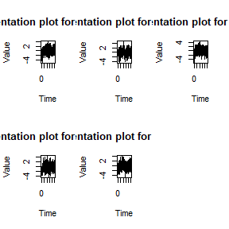

```r
par(mfrow=c(2,3))
plot(result, cpts.col = 'red')
```

### Segmentation for Multivariate Covariance

```r
library(mvtnorm)
set.seed(10)
reptime <- 2
d <- 4
n <- 1000
sigma_cross <- list(exchange_cor_matrix(d,0.2),
                    2*exchange_cor_matrix(d,0.5),
                    4*exchange_cor_matrix(d,0.5))
rho_sets <- c(0.3,0.3,0.3)
mean_shift <- c(0,0,0) # with mean change
cp_sets <- round(c(0,n/3,2*n/3,n))
ts <- MAR_MTS_Covariance(n, reptime, rho_sets, cp_sets, sigma_cross)
noCP <- length(cp_sets)-2
no_seg <- length(cp_sets)-1
for(rep_index in 1:reptime){
  for(index in 1:no_seg){ # Mean shift
    tau1 <- cp_sets[index]+1
    tau2 <- cp_sets[index+1]
    ts[[rep_index]][,tau1:tau2] <- ts[[rep_index]][,tau1:tau2] +
      mean_shift[index]
    }
}
ts <- ts[[1]]

# grid_size undefined
result <- SNSeg_Multi(ts, paras_to_test = "covariance",
                      confidence = 0.9, grid_size_scale = 0.05,
                      grid_size = NULL, plot_SN = FALSE, est_cp_loc = FALSE)
# grid_size defined
result <- SNSeg_Multi(ts, paras_to_test = "covariance",
                      confidence = 0.9, grid_size_scale = 0.05,
                      grid_size = 81, plot_SN = FALSE,
                      est_cp_loc = TRUE)
# Estimated change-point locations
result$est_cp
```

```
#> [1] 321 651
```

```r
# Parameter estimates (covariance estimate) of each segment
SNSeg_estimate(result)
```

```
#> $covariance
#> $covariance[[1]]
#>           [,1]      [,2]      [,3]      [,4]
#> [1,] 1.2368168 0.1663240 0.1418070 0.3158124
#> [2,] 0.1663240 1.1621812 0.2084182 0.2866718
#> [3,] 0.1418070 0.2084182 1.0752777 0.2100478
#> [4,] 0.3158124 0.2866718 0.2100478 1.1186048
#>
#> $covariance[[2]]
#>          [,1]     [,2]      [,3]      [,4]
#> [1,] 1.976111 1.195347 1.1709615 1.1058696
#> [2,] 1.195347 2.531295 1.3189884 1.1820544
#> [3,] 1.170961 1.318988 2.5833800 0.9738675
#> [4,] 1.105870 1.182054 0.9738675 2.0120061
#>
#> $covariance[[3]]
#>          [,1]     [,2]     [,3]     [,4]
#> [1,] 4.188069 2.490367 2.269477 1.858629
#> [2,] 2.490367 4.793427 2.475150 1.973066
#> [3,] 2.269477 2.475150 4.534520 2.201183
#> [4,] 1.858629 1.973066 2.201183 4.293322
#>
#>
#> attr(,"class")
#> [1] "SNSeg_estimate"
```

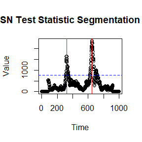

```r
# SN-based test statistic segmentation plot
SN_stat <- max_SNsweep(result, plot_SN = TRUE, est_cp_loc = TRUE,
                       critical_loc = TRUE)
```

```r
summary(result)
```

```
#> covarianceThere are 2 change-points detected at 90th confidence level based on the change in multivariate
#>
#> The detected change-point location(s) are 321,651 with a grid_size of 81
#>
#> The critical value of SN-based test is 755.435572948992
```

```r
print(result)
```

```
#> The detected change-point location(s) are 321,651
```

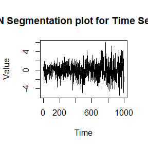

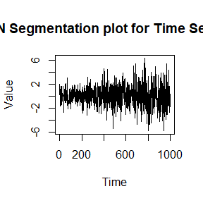

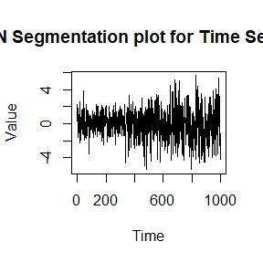

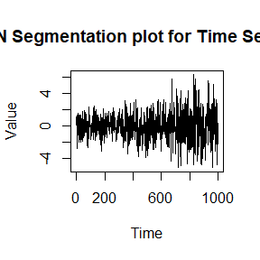

```r
par(mfrow=c(1,1))
plot(result, cpts.col = 'red')
```

## Examples: `SNSeg_HD`

The function `SNSeg_HD` performs change-points estimation for high-dimensional time series (dimension greater than 10) using the change in high-dimensional means. For usage examples of `SNSeg_HD`, we provide the followig code:

```r
n <- 600
p <- 100
nocp <- 5
cp_sets <- round(seq(0,nocp+1,1)/(nocp+1)*n)
num_entry <- 5
kappa <- sqrt(4/5) # Wang et al(2020)
mean_shift <- rep(c(0,kappa),100)[1:(length(cp_sets)-1)]
set.seed(1)
ts <- matrix(rnorm(n*p,0,1),n,p)
no_seg <- length(cp_sets)-1
for(index in 1:no_seg){ # Mean shift
  tau1 <- cp_sets[index]+1
  tau2 <- cp_sets[index+1]
  ts[tau1:tau2,1:num_entry] <- ts[tau1:tau2,1:num_entry] +
    mean_shift[index] # sparse change
}
# SN segmentation plot
# grid_size undefined (plot the first 3 time series)
result <- SNSeg_HD(ts, confidence = 0.9, grid_size_scale = 0.05,
                   grid_size = NULL, plot_SN = FALSE, est_cp_loc = TRUE,
                   ts_index = c(1:3))
# grid_size defined (plot the 1st, 3rd and 5th time series)
result <- SNSeg_HD(ts, confidence = 0.9, grid_size_scale  = 0.05,
                   grid_size = 52, plot_SN = FALSE, est_cp_loc = TRUE,
                   ts_index = c(1,3,5))
# Estimated change-point locations
result$est_cp
```

```
#> [1] 100 195 300 404 498
```

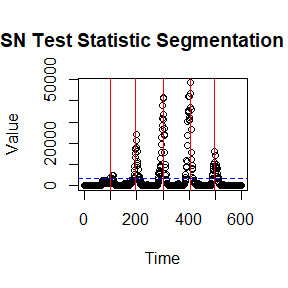

```r
# Parameter estimates (high-dimensional means) of each segment
summary.stat <- SNSeg_estimate(result)
# SN-based test statistic segmentation plot
SN_stat <- max_SNsweep(result, plot_SN = TRUE, est_cp_loc = TRUE,
                       critical_loc = TRUE)
```

```r
summary(result)
```

```
#> There are 5 change-points detected at 90th confidence level based on the change in high-dimensional means
#>
#> The detected change-point location(s) are 100,195,300,404,498 with a grid_size of 52
#>
#> The critical value of SN-based test is 3616.27057754713
```

```r
print(result)
```

```
#> The detected change-point location(s) are 100,195,300,404,498
```

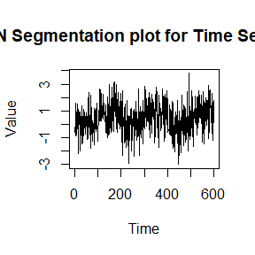

```r
plot(result, cpts.col = 'red', ts_index = c(1:3))
```

[output not shown]

We note that only the selected time series were plotted by setting values for `ts_index`.